# The Politics of Aid and Corruption: Evidence from Democracies and Autocracies

Author

Mariam Sajid

Abstract

Over the past few decades, foreign aid has played an integral role in promoting international development, but its governance effects remain contested. This study examines whether the impact of aid on corruption differs by regime type. Using a quantitative Difference-in-Differences (DiD) event study, I analyze low- and middle-income countries in the Global South that receive at least 25% of their Gross National Income (GNI) in Official Development Assistance (ODA), and see how the corruption levels change. The results show stark contrasts: in autocracies, large aid inflows lead to sustained increases in corruption, while in democracies aid initially raises corruption but later contributes to stabilization and eventual decline. Control countries experience little change. These patterns suggest that institutional context—especially the presence or absence of electoral accountability—shapes whether aid entrenches misuse or fosters reform. For policymakers, recognizing that regime type mediates aid’s governance effects is crucial for designing conditionalities and improving aid effectiveness.

# 1 Introduction

Foreign aid has long been a cornerstone of international development strategy, with donors channeling billions of dollars annually to assist low- and middle-income countries in addressing poverty, inequality, infrastructure deficits, and governance challenges. From the Marshall Plan to the Sustainable Development Goals, aid has been framed as a catalyst for both economic growth and institutional reform. Yet its effectiveness remains deeply contested (Rajan and Subramanian 2008; Easterly 2003). Some scholars argue that aid can entrench poor governance and increase corruption—either by incentivizing politically strategic allocation, such as targeting voter-rich areas while neglecting those most in need (Jablonski 2014), or by expanding discretionary resources in weakly accountable states (Svensson 2000; Knack 2001; Bueno de Mesquita and Downs 2003; Djankov, Montalvo, and Reynal-Querol 2008). Others contend that outcomes depend heavily on donor intent: when donors impose conditionality and oversight, aid can instead promote positive institutional outcomes (Bermeo 2011; Brown 2005).

Two frequently studied factors in this debate are regime type and corruption. Democracies are often presumed to be more accountable to their citizens, constrained by checks and balances and motivated by electoral incentives to allocate aid in line with public needs (Kono and Montinola 2009; Kosak 2003). In contrast, autocracies—lacking transparency, electoral pressures, and smaller electoral turnover rate —may face fewer constraints on executive discretion, allowing greater room for the politicization or misuse of aid (Svensson 2000; Brautigam and Knack 2004; Chiozza and Goemans 2003).

While regime type and corruption are frequently studied in isolation (Jenkins 2001), far less attention has been paid to how these two variables interact in shaping foreign aid outcomes. Most analyses treat aid or regime type as independent explanatory factors, overlooking the ways they may jointly influence governance. This oversight is significant, especially given that many aid-recipient countries exist along a spectrum between democracy and autocracy and often experience political transitions over time. Failing to account for regime type risks overgeneralizing aid’s impact and designing policies misaligned with local political realities. This study seeks to address that gap by examining how regime type moderates the relationship between foreign aid and corruption.

Specifically, I ask: How do the effects of receiving foreign aid on corruption vary by regime type? I investigate whether democratic and autocratic regimes experience divergent corruption outcomes following large aid inflows. This question is not only theoretical—it carries practical implications for policymakers and donors concerned with maximizing aid effectiveness. If aid is more likely to reduce corruption in democracies and exacerbate it in autocracies (or vice versa), then foreign assistance strategies must be adapted to political context.

My research finds that levels of transparency and institutional accountability in recipient governments significantly shape how aid is allocated and its developmental impact. In countries with higher transparency and lower corruption, aid is more likely to be distributed equitably and used efficiently. Conversely, in states with weaker accountability structures, aid inflows are often accompanied by misuse or misallocation of funds. Crucially, these patterns are shaped by regime type. Autocracies whose GDP comprises 25% or more in foreign aid tend to experience rising corruption levels after receiving aid, while democracies under similar aid conditions exhibit far smaller increases in corruption. Control countries—those below the aid threshold—show minimal change, suggesting that large aid spikes provoke different governance responses depending on institutional constraints.

While previous studies have analyzed corruption or regime type separately, this research contributes by examining how they interact to influence aid outcomes. These findings are especially relevant for scholars and practitioners in development economics, international relations, and public policy. By highlighting the moderating role of regime type, this study supports the case for more context-sensitive aid strategies. Recognizing how institutional quality shapes aid outcomes allows donors to implement conditionalities or oversight mechanisms that mitigate waste and improve effectiveness. As global aid budgets face growing scrutiny, understanding how governance systems mediate aid’s impact on corruption is more important than ever.

# 2 Aid, Accountability, and Authoritarianism: A Regime-Based Review of Corruption Outcomes

Corruption—defined by Transparency International as the abuse of entrusted power for private gain—has been a persistent point of contention in international politics for over a century (Boone 1996). As foreign aid has become an increasingly prominent tool in development efforts worldwide, understanding its relationship with corruption is critical for evaluating its effectiveness. However, this relationship remains highly contested. With scholars arguing over varing topics in relation to it: it’s effectiveness other methods of income (Collier 2006), the emergence of infighting due to it (Nunn and Qian 2014), Some scholars, such as Qian (2015), argue that foreign aid can increase corruption by reducing governments’ reliance on tax revenues, thereby weakening their accountability to citizens. This dynamic is echoed in Ali et al. (2019)’s quantitative analysis of several Asian democracies (Bangladesh, Sri Lanka, Singapore, and India), which found that increases in foreign aid were associated with rising scores on the Corruption Perceptions Index (CPI)—indicating worsening perceived corruption.

Conversely, others suggest that foreign aid can reduce corruption. For example, Asongu (2012) and Samreth and Okada (2012) find a negative relationship between aid and corruption in 53 African countries, suggesting that aid—under certain conditions—can improve governance. These divergent findings may, in part, be explained by regime type: while the Asian countries in Ali et al. (2019)’s study are democracies, many African states included in Asongu (2012)’s sample are autocracies. This suggests that political institutions may mediate how aid affects corruption, warranting closer attention to the interaction between regime type and governance outcomes. In additon when looking at countries, ignorant of regime type, Tavares (2003) found that aid reduced corruption.

When examining regime type specifically, the literature diverges into three primary camps. The first argues that foreign aid increases corruption in autocratic states while having little to no negative effect in democracies. The second contends that aid undermines governance regardless of regime type. The third emphasizes the role of donor intent and conditionality, rather than regime type alone, in determining aid outcomes.

A substantial body of research supports the first view: that foreign aid exacerbates corruption in autocracies but has limited or more benign effects in democracies. Kono and Montinola (2009) provides a foundational contribution to this perspective, arguing that autocratic leaders are better positioned to “stockpile” aid, using it to withstand economic shocks, strengthen patronage networks, and suppress dissent. In contrast, democratic leaders are constrained by institutional oversight, which compels them to allocate aid more transparently and in ways aligned with public accountability. Similarly, Nieto-Matiz and Schenoni (2020) demonstrates that aid can entrench autocratic survival unless donors exercise strong political leverage. Where such leverage is absent, autocrats may appropriate aid to consolidate power and deepen systemic corruption. These scholars collectively argue that without democratic checks and balances or credible external pressure, foreign aid may inadvertently bolster authoritarian regimes and their corrupt practices.

The second camp maintains that foreign aid erodes governance across all regime types. Rather than improving accountability, aid can create perverse incentives, weaken institutions, and reduce responsiveness to domestic citizens by diminishing reliance on tax revenue. Knack (2003) finds that aid fosters corruption and weakens emerging democracies by eroding state institutions. Similarly, Kaylvitis and Vlachaki (2012) links aid flows with a lower likelihood of democratization, and Bader and Faust (2014) argues that aid stabilizes incumbents regardless of regime type, thereby reducing prospects for meaningful political change. In this view, aid enables governments—democratic or autocratic—to avoid hard reforms and remain unaccountable, especially in the absence of robust monitoring mechanisms.

The third perspective highlights the importance of donor intent and strategy. Rather than being determined solely by recipient characteristics, aid outcomes are seen as a function of how donors design and implement assistance. Bermeo (2011) contends that democratic donors are more likely to promote good governance and democracy through aid, while strategically motivated donors may prioritize short-term interests over institutional reform. Similarly, Brown (2005) emphasizes how donor inconsistency and weak follow-through undermine reform efforts, noting that even well-intentioned aid can fail when donors fail to apply conditionalities transparently or prioritize commercial or geopolitical interests over accountability.

While each of these camps offers valuable insights, few studies integrate regime type, donor leverage, and transparency outcomes into a unified analysis. This leaves critical questions unresolved: How do regime characteristics interact with donor strategies to influence aid effectiveness? Under what conditions does aid reduce corruption or exacerbate it? This paper addresses these questions by focusing specifically on the interaction between regime type and transparency in the management of foreign aid.

The central aim of this study is to examine how transparency and corruption in the use of foreign aid differ between democratic and authoritarian regimes. Unlike existing literature that often centers on regime survival or democracy promotion, this research focuses on governance outcomes—namely, corruption and transparency—as the primary dependent variables. This shift allows for a more grounded understanding of how aid is implemented in different political contexts.

By highlighting how institutional context mediates aid’s impact, this study contributes a nuanced framework for understanding aid effectiveness. Foreign aid remains a central tool of international engagement, yet its impact depends not only on donor intent but on how it is administered—and on whom. Identifying when and why aid promotes transparency or enables corruption is crucial for crafting more effective, accountable aid strategies. This research ultimately seeks to inform how donors can tailor their assistance to align with the political and institutional realities of recipient states, ensuring that aid contributes not just to development outcomes, but to more transparent and just governance.

# 3 Theory and Argument

In this paper, I argue that foreign aid has a higher chance in increasing corruption in autocratic regimes while having a little effect in democracies. My argument is based on how in autocracies there are weak accountability systems with limited oversight; their absence could allow for leaders to divert aid for personal or political gain (Wright 2009). However democracies typically have stronger institutions, such as elections, independent media, and civil society organizations, which can monitor how aid is used and can limit corruption leading to less of a growth in corruption (Levitsky and Way 2002) . Foreign aid is defined as Net Official Development Assistance (ODA) received as a percentage of Gross National Product (GNP), which reflects the amount of aid a country receives relative to the size of its economy in order to keep all of the country’s aid on the same scale allowing for less error while analyzing my data.) In addition, based on this framework, I have developed two hypotheses: (1) the increase in corruption is more substantial in recipient autocracies than in recipient democracies, and (2) democratic recipient institutions reduce the extent to which aid contributes to corruption. Figure 1.A , as seen below, summarizes my arguments. It presents a schematic way of how autocracies and democracies differ in structure and mechanisms allowing for varied paths for how foreign aid is allocated and used.

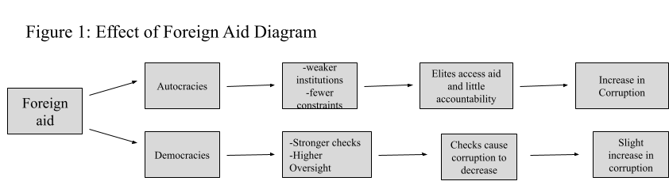

# 4 Methods

This study employs a multivariable quantitative differences-in-differences (DiD) approach to examine the relationship between Official Development Assistance (ODA) inflows and corruption across countries in the Global South—regions where foreign aid flows tend to be concentrated and where governance challenges, such as corruption, are more prevalent.

For this analysis, the Global South is defined as low- and middle-income countries located in Africa, Latin America, South and Southeast Asia, as well as parts of the Middle East and Oceania. These countries face shared historical and structural challenges rooted in broader postcolonial and geopolitical contexts often discussed in development literature (e.g., Mahler 2018; Dados and Conell 2012). This classification follows the World Bank’s income groupings (low- and lower-middle income) alongside its regional groupings, including Sub-Saharan Africa, Middle East & North Africa, South Asia, East Asia & Pacific, Latin America & the Caribbean, and Oceania.

Specifically, the Global South sample in this study includes the following 122 countries displayed on Figure 1, Figure 1 below:

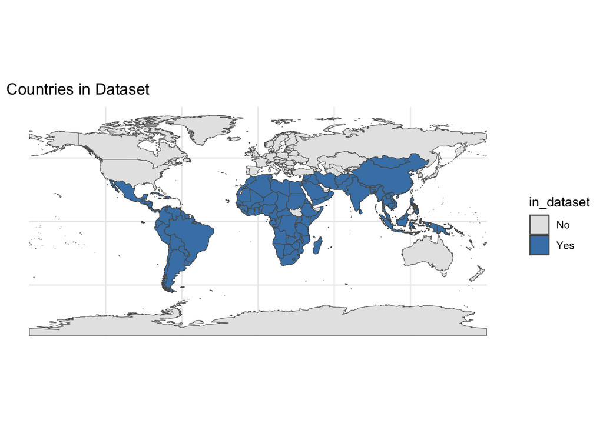

Figure 1

Focusing on the Global South allows the analysis to target contexts where foreign aid is likely to have a significant political impact, and where there is meaningful variation in both regime type and corruption levels. The primary outcome variable is the Corruption Perception Index (CPI), a widely used measure capturing perceived levels of public sector corruption on a scale from 0 (highly corrupt) to 100 (very clean). To ensure consistency across time, all CPI data were rescaled due to a change in scoring methodology post-2012: all pre-2012 CPI values were multiplied by ten to align with the later scale, enabling valid longitudinal comparisons.

Regime type data were sourced from the Varieties of Democracy (V-Dem) Core dataset. Countries were categorized as democracies or autocracies based on their polyarchy index [^1], using a cutoff value of 0.5. This threshold, commonly employed in the literature (Luhrmann, Tannenberg, and Lindberg (2018), reflects the midpoint of the 0–1 index scale, where 0 indicates non-democratic and 1 fully democratic. This classification serves as a key variable to differentiate the effects of aid by political regime context.

The treatment variable is defined as the first year, since 2005, when a country’s ODA inflows reached or exceeded 25% of GNI. Countries that never reached this threshold were assigned a synthetic treatment year to serve as controls within the event study framework.

The primary empirical specification uses an event-study DiD design, with the following model:
$$\text{CPI}_{it} = \sum_{k = -4}^{10} \beta_k \cdot \mathbb{1}(\text{EventTime}_{it} = k) + \alpha_i + \gamma_t + \varepsilon_{it}$$

where $\text{CPI}{it}$ is the corruption score for country $i$ in year $t$, and $\mathbb{1}(\text{EventTime}_{it} = k)$ is an indicator for each year relative to treatment, defined as the year when at least 25% of GNI is composed of foreign aid. Country fixed effects ($\alpha_i$) and year fixed effects ($\gamma_t$) control for time-invariant country characteristics and common global shocks, respectively. Standard errors are at the country level. The dataset is restricted to low- and middle-income countries within the Global South.

Event time is calculated as the difference between each observation year and the country-specific treatment year, allowing for a time window from four years before to ten years after treatment. This window enables observation of pre-treatment trends and post-treatment effects over a sufficient duration. Data from the three primary sources—CPI, V-Dem, and ODA—were merged by ISO3 country codes and year, ensuring standardized country identifiers across datasets. The resulting data was grouped into three categories: democracies with ODA ≥ 25% of GNI, autocracies with ODA ≥ 25% of GNI, and control countries that never reached the treatment threshold.

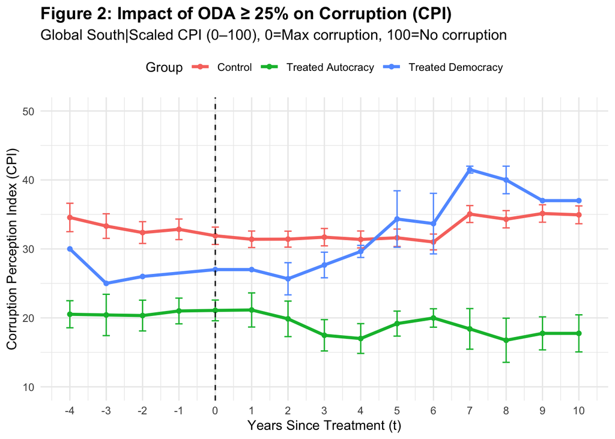

Figure 2

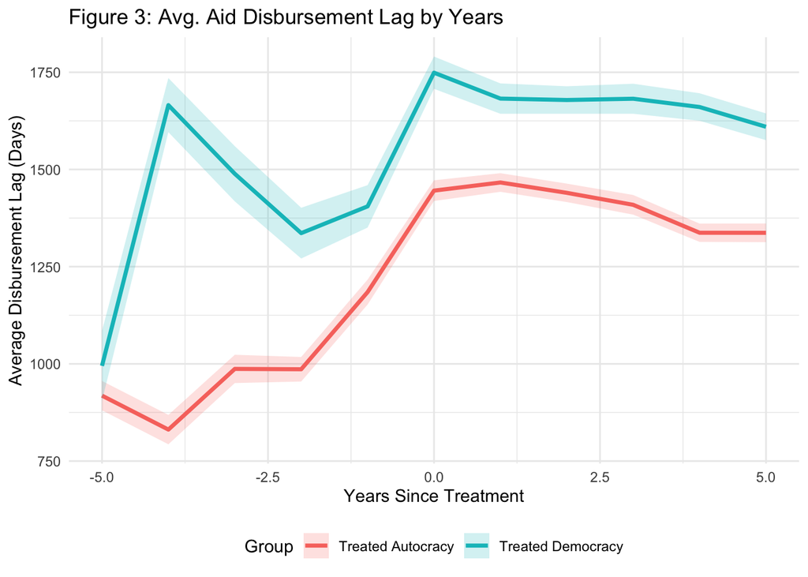

Figure 3

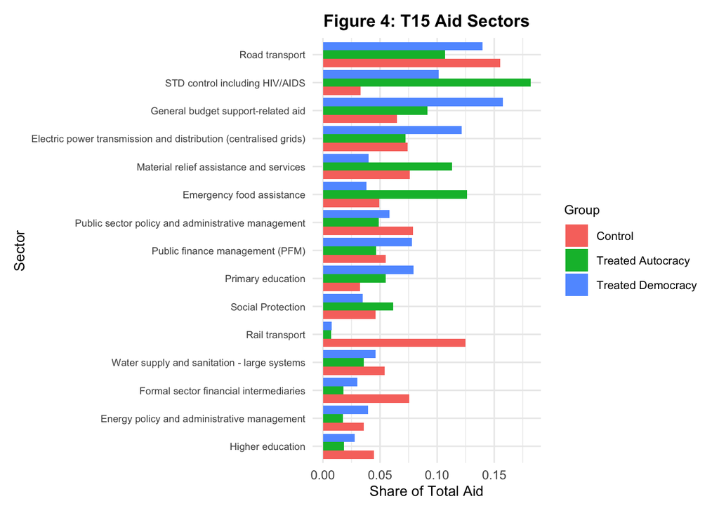

Figure 4

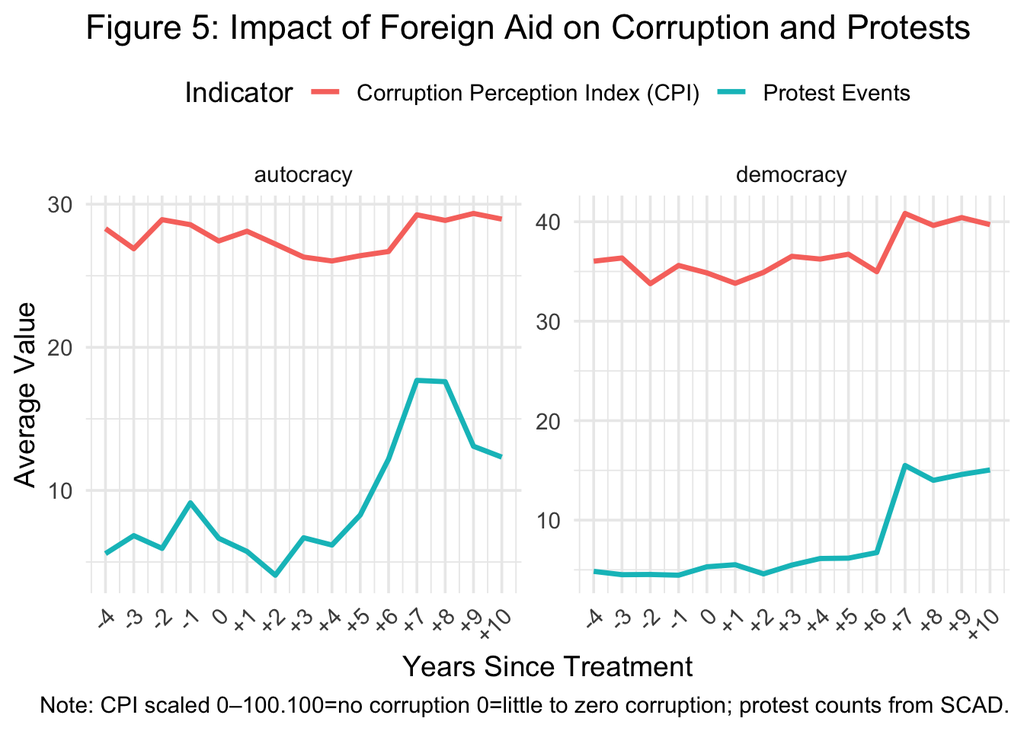

Figure 5

By integrating multiple data sources—including CPI, V-Dem indices, World Bank WDI for ODA, OECD CRS, and SCAD for protest data—this research design facilitates a nuanced understanding of the complex relationships between foreign aid, regime type, governance outcomes, and societal responses in Global South low- and middle-income countries.

Nevertheless, this approach carries several assumptions and limitations. First, the DiD event study relies on the parallel trends assumption, positing that treated and control countries would have followed similar corruption trajectories absent high ODA inflows. While country and year fixed effects control for many confounders, this assumption remains untestable directly. Second, the CPI is a perception-based measure that may lag actual corruption changes or be influenced by media and international scrutiny. Additionally, the DiD design shows significant lag in treatment effects; future research could incorporate models accounting for such lags to better capture more instantaneous dynamics. Lastly, focusing exclusively on low- and middle-income countries in the Global South enhances internal validity but may limit generalizability to wealthier or more institutionally stable contexts. Future studies might expand the sample to broader economic groups to examine heterogeneity across income levels.

Taken together, this methodology using CPI, World Bank, SCAD, V-Dem, and CRI, represents an initial attempt to investigate for the causal impact of large foreign aid inflows on corruption while accounting for political regime variation. By employing an event-study approach, scaling CPI consistently, controlling for fixed effects, and disaggregating by regime type, the analysis reveals nuanced patterns in how and under what conditions foreign aid may reduce or exacerbate corruption in the Global South.

# 5 Findings

To further contextualize these trends, Figure 3 adds helpful insight. Among countries that crossed the 25% ODA of GNI threshold, democracies had a higher and longer lag in aid disbursement, while authoritarian regimes had a shorter lag. This is possibly due to how there are fewer bureaucratic checkpoints in autocracies. This lines up with the earlier point: corruption in democracies might not shift immediately because the aid doesn’t go in effect as immediate as autocratic aid.

Finally, Figure 4 dives into how autocracies and democracies actually spend their aid. Autocracies mostly direct it toward crisis management (emergency food assistance, material relief, STD control) whereas democracies spend it on public services and governance, like road transport, general budget support, public finance, and primary education. This is consistent with what Montiola and Easton (2017) found, and helps explain the longer-term institutional impacts in democracies because a significant portion of money is being directed towards institutions and institutional change.

# 6 Discussion

Protests and civic engagement further reinforce this pattern. Rising corruption in democracies often sparks public outcry, which pressures governments to act and improves accountability. In autocracies, protests may occur but are met with repression rather than corrective action. Without independent institutions or electoral incentives, aid tends to be allocated to fungible or short-term relief sectors, leaving corruption entrenched and systemic. Together, these mechanisms show that aid is not inherently good or bad; its effects depend on whether the recipient’s political system can guide resources toward long-term reform.

These results challenge the idea of aid being inherently good or bad regardless of regime type as argued by Asongu (2012); Samreth and Okada (2012); Knack (2003); and Bader and Faust (2014) They suggest that donors should consider not only how much aid is given but also where it goes and the political environment of the recipient. Aid to democracies can reinforce positive governance trajectories, while aid to autocracies risks deepening rent-seeking and poor accountability. Policymakers should therefore prioritize transparency, oversight, and institutional strengthening when designing aid programs.

These findings have broader implications for how scholars and policymakers approach the topic of foreign aid effectiveness. They challenge the one-size-fits-all view of aid by showing that the regime context shapes how aid translates into governance outcomes. Readers should now think more critically about the political and institutional channels through which aid flows, not merely the volume of aid itself.

Despite the contributions of this study, there are several limitations. Most notably, the analysis operates at the national level and does not capture variations within countries, such as semi or fully autonomous regions, where corruption and aid implementation may diverge significantly. This article cannot answer how localized dynamics, such as state-level politics or urban-rural divides, change the effects of foreign aid. Future work could address this by replicating the design with sub national data sets or focusing on case studies.

The study also opens avenues for future research. Scholars could explore the role of sectoral allocation, protest responses, or other governance indicators—such as institutional size and transparency— on a country by country frame on analysis to better understand when and how aid improves outcomes. Finally, the analysis is limited by its national-level focus, which masks local variations in corruption and aid implementation. Future work could examine sub national dynamics or conduct detailed case studies to uncover these finer-grained patterns.

# 7 AI Transparency Statement:

In the course of this project, I used OpenAI’s ChatGPT as a supplementary tool. Its use was limited to two areas: (1) resolving syntactical errors in R Studio code, particularly when I encountered difficulties related to data cleaning and figure generation given my limited and recent exposure to statistics and R, and (2) refining the clarity and flow of my writing in the by suggesting improvements in word choice and grammatical errors.

All use of AI was closely monitored and guided by my Lumiere Research Scholar Program mentor to ensure it was appropriate and responsible. Importantly, all research design decisions, theoretical framing, interpretation of data, and the substantive ideas in this paper are my own. ChatGPT did not generate or interpret results, propose hypotheses, or contribute original insights; it was used strictly as a technical and editorial aid.

All original writing in this paper was produced entirely by me. ChatGPT was used only to refine existing drafts by suggesting edits for clarity, concision, and readability. The core arguments, structure, and substance of the paper—including the literature review, methods, analysis, and discussion—were conceived and written independently by me.

# 8 Appendix

|  | Unique | Missing Pct. | Mean | SD | Min | Median | Max |
| --- | --- | --- | --- | --- | --- | --- | --- |
| year | 15 | 0 | 2008.7 | 4.0 | 2001.0 | 2009.0 | 2015.0 |
| oda_gni | 1343 | 0 | 5.1 | 7.6 | −0.6 | 2.2 | 79.5 |
| treatment_year | 7 | 0 | 2005.2 | 1.1 | 2005.0 | 2005.0 | 2018.0 |
| event_time | 15 | 0 | 3.5 | 4.0 | −4.0 | 4.0 | 10.0 |
| cpi_scaled | 143 | 0 | 31.9 | 12.0 | 4.0 | 29.0 | 78.0 |

## References

Ali, Muhammed, Amna Sohail, Lubna Khan, and Chin Hang Puah. 2019. “The relationship between foreign aid and corruption: a case of selected Asian countries.” *Journal of Financial Crime* 26 (3): 692–704.

Asongu, Simplice. 2012. “Backing Despots? Foreign Aid and the Survival ofAutocratic Regimes.” *African Governance and Development Institute (AGDI)*.

Bader, Julia, and Jorg Faust. 2014. “Foreign Aid, Democratization, and Autocratic Survival.” *International Studies Review* 16: 575–95.

Bermeo, Sarah. 2011. “Foreign Aid and Regime Change:A Role for Donor Intent.” *World Devolpment* 39 (11): 2021–31.

Boone, P. 1996. “Politics and the effectiveness of foreign aid.” *European Economic Review* 40 (2): 289–329.

Brautigam, Deborah A., and Stephen Knack. 2004. “Foreign Aid, Institutions, and Governance in Sub-Saharan Africa.” *Economic Development and Cultural Change* 52 (2): 255–85.

Brown, Stephen. 2005. “Foreign Aid and Democracy Promotion:Lessons from Africa.” *The European Journal of Development Research,* 17 (2): 179–98.

Bueno de Mesquita, Bruce, and George W. Downs. 2003. “Intervention and Democracy.” *Cambridge University Press* 60: 627–49.

Chiozza, Giacomo, and H. E. Goemans. 2003. “Peace through Insecurity: Tenure and International Conflict.” *Journal of Conflict Resolution* 47 (4): 443–67.

Collier, Paul. 2006. “Is aid oil? An analysis of whether aid accelerates development.” *World Devolpment* 34 (9): 1482–97.

Dados, Nour, and Raewyn Conell. 2012. “The Global South.” *Contexts* 11 (1): 12–13.

Djankov, S., J. G. Montalvo, and M. Reynal-Querol. 2008. “The Curse of Aid.” *Journal of Economic Growth* 13 (3): 169–94.

Easterly, William. 2003. “Can Foriegn Aid Buy Growth?” *Journal of Economic Perspectives* 17 (3): 23–48.

Jablonski, Ryan. 2014. “How aid targets votes: the impact ofelectoral incentives on foreign aid distribution.” *World Politics* 66 (2): 293–330.

Jenkins, Rob. 2001. *Mistaking "Governance" for "Politics":Foreign Aid, Democracy and the Construction of Civil Society*. Edited by Sudipta Kavirag and Sunil Khilnani. *Cambridge University Press*. Vol. 250. Cambriddge, UK: Cambridge Univeristy Press.

Kaylvitis, Sarantis, and Irene Vlachaki. 2012. “When Does More Aid Imply Less Democracy?An Empirical Examination.” *European Journal of Political Economy* 28 (1): 132–46.

Knack, Stephen. 2001. “Aid Dependence and the Quality of Governance:A Cross-Country Empirical Analysis.” *Southern Economic Journal* 68 (2): 310–29.

———. 2003. “Does Foreign Aid Promote Democracy?” *International Studies Quarterly* 48 (1): 251–66.

Kono, Daniel, and Gabriella Montinola. 2009. “Does Foreign Aid Support Autocrats, Democrats,or Both?” *The Journal of Politics* 71 (2): 1–15.

Kosak, Stephen. 2003. “Effective Aid: How Democracy Allows Development Aid to Improve the Quality of LifeAuthor links open overlay panel.” *World Devolpment* 31 (1): 1–12.

Levitsky, Steven, and Lucan A. Way. 2002. “Elections Without DemocracyThe Rise of Competitive Authoritarianism.” *Journal of Democracy* 13 (2): 51–65.

Luhrmann, Anna, Marcus Tannenberg, and Staffan I. Lindberg. 2018. “Regimes of the World (RoW): Opening New Avenues for the Comparative Study of Political Regimes."Politics and Governance".” *Politics and Governance* 6 (1): 60–77.

Mahler, Anne. 2018. *From the Tricontinental to the global South: Race, radicalism, and transnational solidarity*. North Carolina: Duke University Press.

Montiola, Gabriella, and Malcom Easton. 2017. “Remittances, Regime Type, and Government Spending Priorities.” *Studies in Comparative International Development* 52: 349–71.

Nieto-Matiz, Camilo, and Luis Schenoni. 2020. “Backing Despots? Foreign Aid and the Survival of Autocratic Regimes.” *Democracy and Security* 16: 36–58.

Nunn, Nathan, and Nancy Qian. 2014. “US Food Aid and Civil Conflict.” *American Economic Review* 104 (6): 1630–66.

Qian, Nancy. 2015. “Making Progress on Foreign Aid.” *Annual Review of Economics* 7: 277–308.

Rajan, Raghuram G., and Arvind Subramanian. 2008. “Aid and Growth: What Does the Cross-Country Evidence Really Show?” *The Review of Economics and Statistics* 90 (4): 643–45.

Samreth, Sovannroeun, and Keisuke Okada. 2012. “The effect of foreign aid on corruption: A quantile regression approach.” *Economics Letters* 115 (2): 240–43.

Svensson, Jakob. 2000. “Foreign aid and rent-seeking.” *Journal of International Economics* 51: 436–61.

Tavares, Jose. 2003. “Does Foreign Aid Corrupt?” *Economic Letters* 79 (1): 99–106.

Wright, Joseph. 2009. “How Foreign Aid Can Foster Democratizationin Authoritarian Regimes.” *American Journal of Political Science* 53 (3): 552–71.

## Footnotes

[^1]: The V-Dem Polyarchy index operates by having anonymous professionals judge countries on 400+ indicators on the five different conceptions of democracy (electoral, liberal, parcipatory, liberal, and egalitarian). These ratings are then aggregated and measured using their measuring system.